# **Unsupervised Learning Project: AllLife Bank Customer Segmentation**

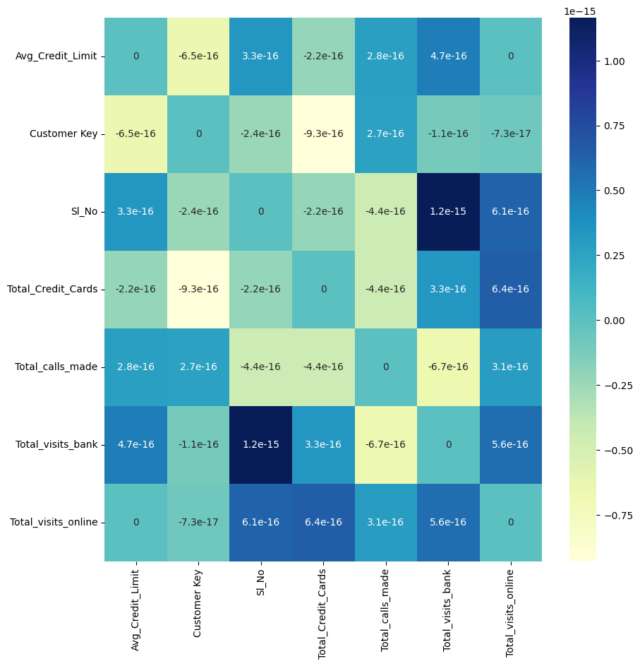

```python
plt.figure(figsize  = (10, 10))
#confirming that no serious correlation changes were made as a result of dropping row duplicates
sns.heatmap(data.corr()-av_data.corr(), annot = True, cmap = "YlGnBu")

plt.show()
```

**Observations**

- Customer Key has predicably low correlations with an other variables.
- We have modest correlations between credit limit, total number of credit cards, and online visits.
- Online visits is negatively correlated with in-person visits, which makes sense. As a result, people with more credit cards and higher credit limit use online more but call less.
- Serial number is surprisingly correlated with number of credit cars, credit limit, and bank visits, while being inverse correlated to total calls made. This would suggest that there is ordering to the customer serial number, most likely a time ordering. Later customers might be assigned later serial numbers and these customers are heavier card users with more bank visits. Some of this might also be a larger number of similar customers coming in in a batch (e.g. all from one referral, one business, etc..). Let's investigate....

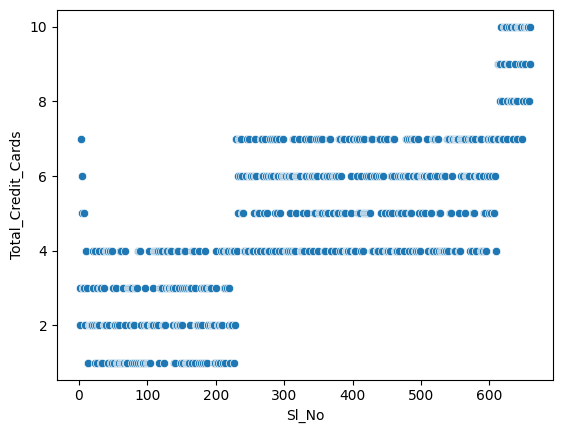

```python
sns.scatterplot(x=data['Sl_No'], y=data['Total_Credit_Cards'])
```

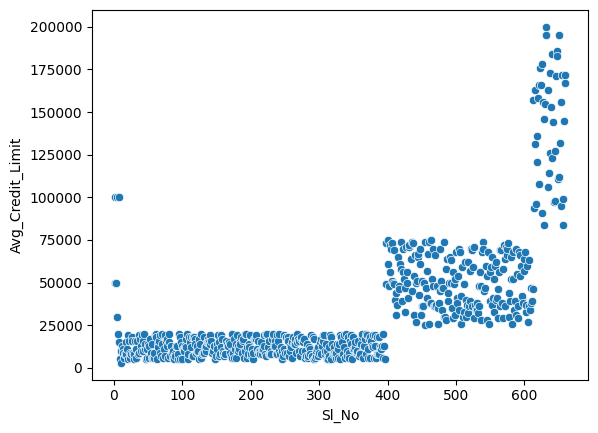

```python
sns.scatterplot(x=data['Sl_No'], y=data['Avg_Credit_Limit'])
```

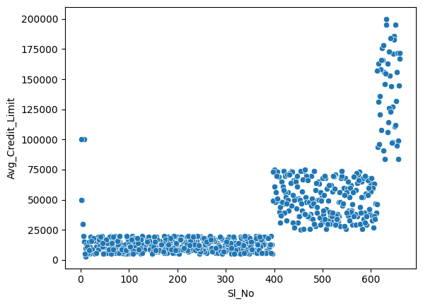

```python
#confirming robustness against dropping row duplicates
sns.scatterplot(x=av_data['Sl_No'], y=av_data['Avg_Credit_Limit'])
```

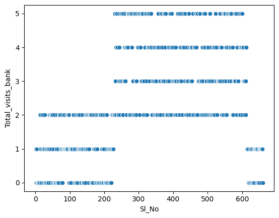

```python
sns.scatterplot(x=data['Sl_No'], y=data['Total_visits_bank'])
```

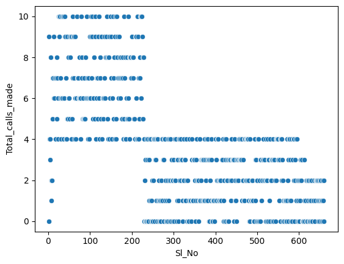

```python
sns.scatterplot(x=data['Sl_No'], y=data['Total_calls_made'])
```

It is uneqiuivocally clear that we are getting batches of similiar customers being assigned adjacent Customer Serial Numbers. Again, this might be time-ordering or the system might be assigning a Serial Number based on another attribute such as branch location.

These blocks are likely overwhelming all other patterns in the data to produce the correlations we see. Earlier Sl_No's had fewer credit cards, smaller credit limit, fewer total visits, and more calls compared to later Sl_No's.

#### **Scaling the data**

```python
#dropping the identification column, which holds no information. Keeping Serial Number
data_new = data.drop(columns = ["Customer Key"])
```

```python
# Scaling the data and storing the output as a new DataFrame

scaler = StandardScaler()

data_scaled = pd.DataFrame(scaler.fit_transform(data_new), columns = data_new.columns)

data_scaled.head()
```

|  | Sl_No | Avg_Credit_Limit | Total_Credit_Cards | Total_visits_bank | Total_visits_online | Total_calls_made |
| --- | --- | --- | --- | --- | --- | --- |
| 0 | -1.722857 | 1.767076 | -1.241704 | -0.858568 | -0.546642 | -1.257006 |
| 1 | -1.717612 | 0.423440 | -0.780379 | -1.471163 | 2.516526 | 1.884177 |
| 2 | -1.712366 | 0.423440 | 1.064922 | -0.858568 | 0.134062 | 0.139075 |
| 3 | -1.707121 | -0.114014 | 0.142271 | -0.858568 | -0.546642 | 0.139075 |
| 4 | -1.701875 | 1.767076 | 0.603597 | -1.471163 | 3.197230 | -0.209945 |

```python
#checking that data have scaled properly
data_scaled.describe().T
```

|  | count | mean | std | min | 25% | 50% | 75% | max |
| --- | --- | --- | --- | --- | --- | --- | --- | --- |
| Sl_No | 655.0 | 8.678385e-17 | 1.000764 | -1.722857 | -0.865232 | -0.007608 | 0.865753 | 1.733868 |
| Avg_Credit_Limit | 655.0 | 0.000000e+00 | 1.000764 | -0.839578 | -0.651469 | -0.436487 | 0.369695 | 4.454348 |
| Total_Credit_Cards | 655.0 | -4.339192e-17 | 1.000764 | -1.703030 | -0.780379 | 0.142271 | 0.603597 | 2.448898 |
| Total_visits_bank | 655.0 | -4.339192e-17 | 1.000764 | -1.471163 | -0.858568 | -0.245973 | 0.979217 | 1.591811 |
| Total_visits_online | 655.0 | 1.084798e-17 | 1.000764 | -0.886994 | -0.546642 | -0.206290 | 0.474414 | 4.218286 |
| Total_calls_made | 655.0 | -1.301758e-16 | 1.000764 | -1.257006 | -0.907986 | -0.209945 | 0.488096 | 2.233197 |

```python
# Creating copy of the data to store labels from each algorithm
data_scaled_copy = data_scaled.copy(deep = True)
```

#### **Applying PCA on scaled data**

```python
# Defining the number of principal components to generate
n = data_scaled.shape[1]
print("Max number of principal components", n)

# Finding principal components for the data
pca1 = PCA(n_components = n, random_state = 1)
data_pca = pd.DataFrame(pca1.fit_transform(data_scaled))

# The percentage of variance explained by each principal component
exp_var1 = pca1.explained_variance_ratio_
```

```
Max number of principal components 6
```

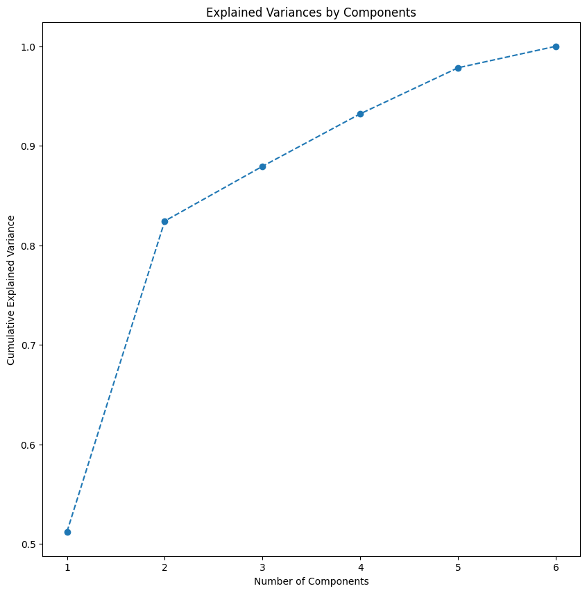

```python
# Visualize the explained variance by individual components
plt.figure(figsize = (10, 10))

plt.plot(range(1, n+1), pca1.explained_variance_ratio_.cumsum(), marker = 'o', linestyle = '--')

plt.title("Explained Variances by Components")

plt.xlabel("Number of Components")

plt.ylabel("Cumulative Explained Variance")

plt.show()
```

```python
pca1.explained_variance_ratio_
```

```
array([0.51221964, 0.31217651, 0.05503363, 0.05271798, 0.04624889,
       0.02160335])
```

82% of the variance can be explained in terms of the first two components. Two is useful for visualization anyway and the first one only covers 51% of the variance.

```python
cols = ['PC1', 'PC2']
pc1 = pd.DataFrame(np.round(pca1.components_.T[:, 0:2], 2), index = data_scaled.columns, columns = cols)
pc1
```

|  | PC1 | PC2 |
| --- | --- | --- |
| Sl_No | 0.52 | -0.01 |
| Avg_Credit_Limit | 0.42 | 0.43 |
| Total_Credit_Cards | 0.50 | 0.06 |
| Total_visits_bank | 0.26 | -0.57 |
| Total_visits_online | 0.06 | 0.67 |
| Total_calls_made | -0.47 | 0.20 |

- The first component is mostly how many credit cards and how many calls were made, as well as customer serial number. We stated above that later serial number went with more cards and more visits and fewer calls.
- The second component is related to online usage and bank visits.

## **K-Means**

We will do this in 3 steps:

1. Initialize a dictionary to store the Sum of Squared Error (SSE) for each K
2. Run for a range of Ks and store SSE for each run
3. Plot the SSE vs K and plot the elbow curve

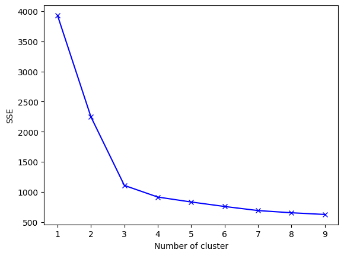

```python
# Empty dictionary to store the SSE for each value of K
sse = {}

# Iterate for a range of Ks and fit the scaled data to the algorithm.
# Use inertia attribute from the clustering object and store the inertia value for that K
for k in range(1, 10):
    kmeans = KMeans(n_clusters = k, random_state = 1).fit(data_scaled)

    sse[k] = kmeans.inertia_

# Elbow plot
plt.figure()

plt.plot(list(sse.keys()), list(sse.values()), 'bx-')

plt.xlabel("Number of cluster")

plt.ylabel("SSE")

plt.show()
```

- The sudden drop in slope at k=3 seems a good place to choose. We've also observed in the raw scatterplots above data highly suggestive for 3 groups.
- Fit the K-means algorithms on the pca components with the number of clusters for the chosen value of K, but it can't hurt to look at the Sil score:

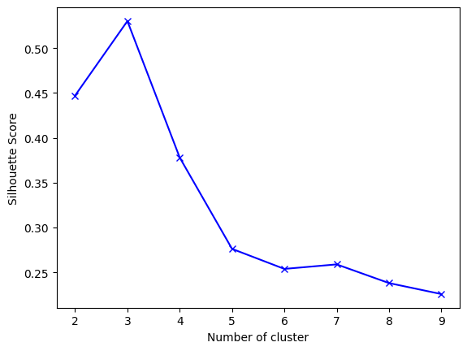

```python
# Empty dictionary to store the Silhouette score for each value of K
sc = {}

# Iterate for a range of Ks and fit the scaled data to the algorithm. Store the Silhouette score for that K
for k in range(2, 10):
    kmeans = KMeans(n_clusters = k, random_state = 1).fit(data_scaled)

    labels = kmeans.predict(data_scaled)

    sc[k] = silhouette_score(data_scaled, labels)

# Elbow plot
plt.figure()

plt.plot(list(sc.keys()), list(sc.values()), 'bx-')

plt.xlabel("Number of cluster")

plt.ylabel("Silhouette Score")

plt.show()
```

```python
print(sc)
```

```
{2: 0.4471156980604948, 3: 0.5301614723103343, 4: 0.37797005979379383, 5: 0.2761713966031751, 6: 0.25381367608664157, 7: 0.2588638417602196, 8: 0.23802592673766823, 9: 0.22576349349319497}
```

This further reinforces our decision to use k=3, as k=3 gives a clear maximum in putting like points in the same cluster and dissimilar points into differnt clusters.

```python
cols = ['PC1', 'PC2', 'PC3']
pca2 = PCA(n_components = 3, random_state = 1)
data_pca = pca2.fit_transform(data_scaled)
transformed_data = pd.DataFrame(data_pca,  columns = cols)
```

#### **Understanding our Clusters**

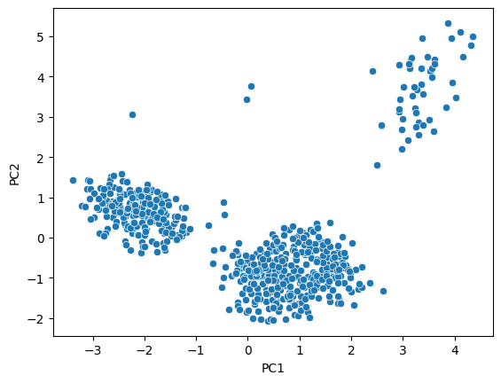

```python
sns.scatterplot(transformed_data, x='PC1', y='PC2')
```

Well, this certainly confirms the 3-batch effect we observed earlier in scatterplots of the raw data. The data were either gathered in a way that naturally created 3 clusters or were otherwise deliberately generated in 3 clusters in mind.

```python
transformed_data_copy = data_scaled.copy(deep = True)
```

```python
kmeans = KMeans(n_clusters = 3, random_state = 1)
kmeans_trans = KMeans(n_clusters = 3, random_state = 1)
kmeans.fit(data_scaled)
kmeans_trans.fit(transformed_data)
# Adding predicted labels to the original data and the scaled data
data_scaled_copy['KMeans_Labels'] = kmeans.predict(data_scaled)
transformed_data_copy['KMeans_Labels'] = kmeans_trans.predict(transformed_data)
data['KMeans_Labels'] = kmeans.predict(data_scaled)
transformed_data['KMeans_Labels'] = kmeans_trans.predict(transformed_data)
```

```python
data['KMeans_Labels'].value_counts()
```

```
1    380
0    226
2     49
Name: KMeans_Labels, dtype: int64
```

Not exactly balanced clusters, but the raw data really do seem to show one cluster being less populated so we feel confident.

```python
# Calculating the mean and the median of the original data for each label
mean = data.groupby('KMeans_Labels').mean()

median = data.groupby('KMeans_Labels').median()

df_kmeans = pd.concat([mean, median], axis = 0)

df_kmeans.index = ['group_0 Mean', 'group_1 Mean', 'group_2 Mean', 'group_0 Median', 'group_1 Median', 'group_2 Median']

df_kmeans.T
```

|  | group_0 Mean | group_1 Mean | group_2 Mean | group_0 Median | group_1 Median | group_2 Median |
| --- | --- | --- | --- | --- | --- | --- |
| Sl_No | 115.460177 | 420.434211 | 610.836735 | 115.5 | 420.5 | 636.0 |
| Customer Key | 55072.902655 | 54945.039474 | 55867.408163 | 54990.5 | 53186.5 | 53834.0 |
| Avg_Credit_Limit | 12831.858407 | 33326.315789 | 140102.040816 | 12000.0 | 31000.0 | 145000.0 |
| Total_Credit_Cards | 2.433628 | 5.507895 | 8.775510 | 2.0 | 6.0 | 9.0 |
| Total_visits_bank | 0.929204 | 3.510526 | 0.591837 | 1.0 | 3.0 | 1.0 |
| Total_visits_online | 3.535398 | 0.973684 | 10.979592 | 4.0 | 1.0 | 11.0 |
| Total_calls_made | 6.827434 | 2.005263 | 1.102041 | 7.0 | 2.0 | 1.0 |

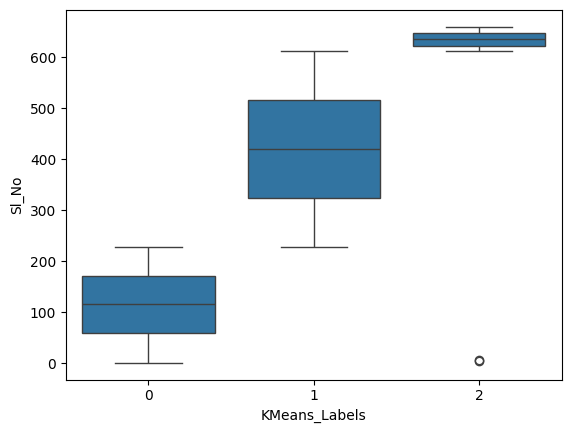

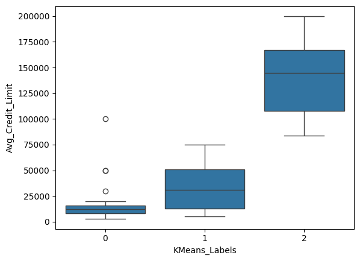

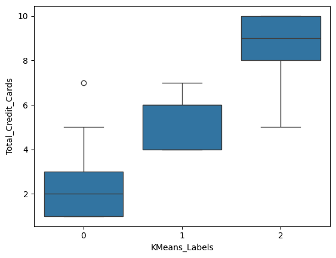

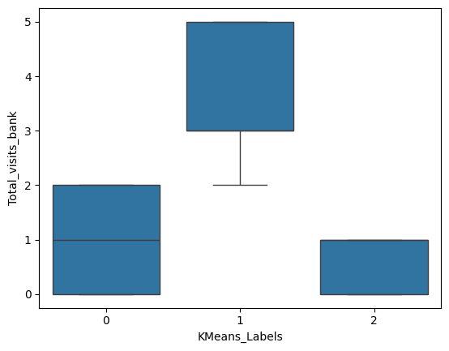

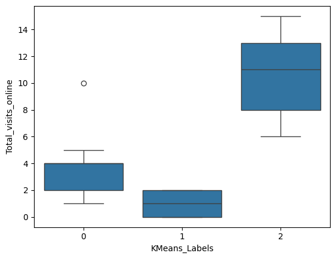

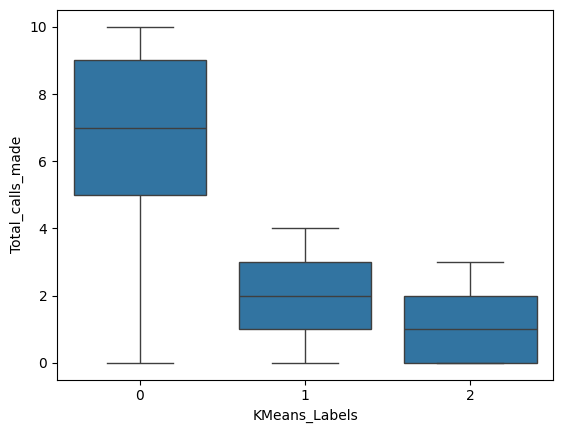

```python
cols_visualise = ['Sl_No', 'Avg_Credit_Limit','Total_Credit_Cards','Total_visits_bank','Total_visits_online','Total_calls_made']
for col in cols_visualise:
    sns.boxplot(x = 'KMeans_Labels', y = col, data = data)
    plt.show()
```

**Cluster Profiles:** Confirming what we already knew:

- Group 0: earlier serial numbers with smaller credit limits, fewer cards, and more total calls.
- Group 1: fewer calls, fewer online visits, a lot more total bank visits, and an intermediate number of cards and credit limits
- Group 2: fewest calls, lots of online visits, few total visits, a lot of credit cards and a high credit limit.

Now, let's just confirm that these clusters came out as we expected from our initial scatter plots, using credit limit as an example:

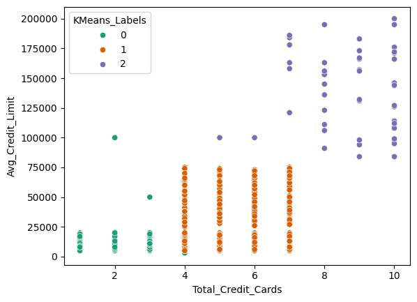

```python
sns.scatterplot(y='Avg_Credit_Limit', x='Total_Credit_Cards', data=data, hue='KMeans_Labels', palette='Dark2')
```

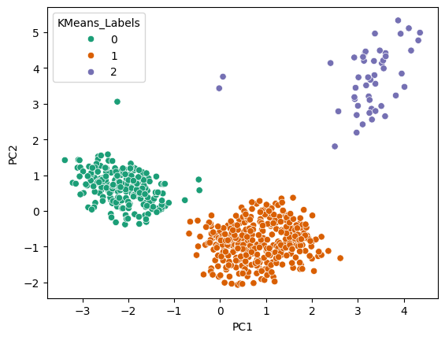

```python
sns.scatterplot(y='PC2', x='PC1', data=transformed_data,  hue='KMeans_Labels', palette='Dark2')
```

Not a perfect clustering, due to a few outliers, but it doesn't like we could do much better than this in any objectively defensible way.